# Msc Thesis Pt2: Predicting NHCI Dropouts

Working document

Author

Affiliation

Brian ODonnell

Charité - Universitätsmedizin Berlin

[Part one](https://iambodo.github.io/projects/nhci_analyses/msc_thesis_pt1_desc.html) imported NHCI visit level data from the DHIS2 export, and described patient dropout patterns over time, location, and patient characteristics. Visit data were deduplicated, and quality of care was described.

Daily LGA-level weather data and weekly state-level market prices, each calculated as trailing 10-day averages. were also introduced. These data were merged into the visit-level data by matching on the “target end date” for the patient’s next appointment, defined as 37 days after the current visit. Thus, they act as instrumental variables for climate and economic conditions during the expected visit window.

In this section we use the above dataset to create a prediction model.

**Implementer decisions should be made on how to define the outcome and put these predictions into patient followup practice:**

1. Is it better to predict return within a “target” 37 day window, or return within a “timely” 90 day window of latest visit?
2. If a patient returns to care >90 days after their latest visit, are they still considered a dropout? Note this is about 17% of all followup visits.
3. If a patient returns to care 1-21 days after latest visit, is this considered a successful followup thats within the target window? Note this is about 5% of all followup visits.

*Goals Summary*

- Use the [tidymodels](https://www.tidymodels.org/start/case-study) workflow for a series of **three logistic regression models** on patient dropout
- Predict patient failure to return after baseline visit (zero visits) using all available variables
- Predict patient dropout-per-opportunity within 90 days (inc. baseline visit and subsequent visits), using all available variables
- Predict patient dropout-per-opportunity within 90 days (incl. baseline visit and subsequent visits), using a parsimonious selection of variables for maximum generalizability and transportability

The model described in manuscript is *MODEL 2*

```r
 #| label: load-packages
 #| include: false
 #| echo: false

library(tidyverse)
library(tidymodels)
library(table1)
library(slider)
library(ggcorrplot)
library(vip)
library(summarytools)
library(glmnet)
library(readxl)
library(kableExtra)
library(effectsize)
library(splines2)
library(probably)
library(RColorBrewer)
library(skimr)
library(DT)
library(themis)
library(ROSE)
library(patchwork)

palette <- brewer.pal(n = 8, name = "Dark2")
palette_reversed <- rev(palette)


mytheme<-
  theme_minimal()+
  theme(
  panel.background = element_rect(fill = "white", color = NA),
  plot.background = element_rect(fill = "white", color = NA),
  legend.background = element_rect(fill = "white", color = NA),
  text = element_text(family="sans"),
  strip.background = element_rect(
    color = "grey70",
    linewidth = 1))

options(ggplot2.discrete.colour = palette, ggplot2.discrete.fill = palette)

theme_set(mytheme)

my_ggsave<-function(x, ...){

  ggsave(paste0(x,".png"), plot=last_plot(),
            path=here::here("figs"),
            dpi=200,
            width=ifelse(is.na(...),7, ...))

    ggsave(paste0(x,".tiff"), plot=last_plot(),
            path=here::here("figs"),
            dpi=200,
            width=ifelse(is.na(...),7, ...))
}
```

# PREDICTION

## Import, Cleaning, and Skim

Importing full dataset, we remove the censored observations. These include the last visit before a patient is marked *Transferred* or *Died*, or those visits after April 1, 2024 (ie no opportunity to finish).

```r
tots_timely_qual_cli_mkt<-readr::read_rds("tots_timely_qual_cli_mkt.rds")

pop_params_top<-readr::read_lines("cli_mkt_params_for_model.txt")


dta_prep_all_models<-tots_timely_qual_cli_mkt %>%
 # remove censored events
    filter(censor==0) %>%
    filter(registration_date>=ymd("2021-01-01")) %>%
    mutate(event_year_month=make_date(year=year(event_date),
                                      month=month(event_date), day="01")) %>%
    mutate(event_year=as.factor(year(event_date))) %>%
    mutate(LGA=str_remove_all(LGA, " Local Government Area")) %>%
    add_count(LGA, event_year_month, name="LGA_monthly_visitLoad") %>%
    add_count(HC, event_year_month, name="HC_monthly_visitLoad") %>%
  # here we remove all visits after a dropout
    mutate(visits_since_dropout=replace_na(visits_since_dropout,0)) %>%
    filter(visits_since_dropout<2) %>%
      mutate(bp_both_na=as.factor(
                      if_else(is.na(bp_diastole_mmhg) & is.na(bp_systole_mmhg),
                             1, 0))) %>%
      mutate(age_group = as.factor(cut(age,
                         breaks = c(0, 30, 45, 60, 75, 110, 100000),
                         include.lowest = T,
                         labels = c("Other", "30-44","45-59",
                                    "60-74", "75-110", "Other")))) %>%
      mutate(med_any=as.factor(if_else(!is.na(med_amlodipine) |
                                        !is.na(med_telmisartan) |
                                        !is.na(med_losartan) |
                                        !is.na(med_hydrochlorothiazide) |
                                        !is.na(other_hypertension_medication),
                                        1, 0))) %>%
      # if there is any medication, assume it is 30 days
      mutate(days_of_medication=as.integer(
                                str_remove(days_of_medication, "days"))) %>%
      mutate(days_of_medication=if_else(med_any==1 & is.na(days_of_medication),
                                        30, days_of_medication)) %>%
      mutate(days_of_medication=replace_na(days_of_medication, 0)) %>%
      mutate(meds_other=if_else(is.na(other_hypertension_medication),
                                      "none","recorded")) %>%
      select(!c(starts_with("other_"))) %>%
   # convert to factors as appropriate
      mutate(across(starts_with("has_"), as.factor)) %>%
      mutate(across(starts_with("p_"), as.factor)) %>%
      mutate(across(starts_with("consent"), as.character)) %>%
      mutate(across(where(is.character), as.factor)) %>%
      arrange(reg_id, appt_tally) %>%
      group_by(reg_id) %>% # days since visit as rolling mean
      mutate(days_since_last_mean = map_dbl(seq_along(appt_tally),
                                  ~ mean(days_since_last[1:.x],
                                     na.rm = TRUE))) %>%
      mutate(days_since_last_sd = map_dbl(seq_along(appt_tally),
                                  ~ sd(days_since_last[1:.x],
                                     na.rm = TRUE))) %>%
      ungroup() %>%
      mutate(across(starts_with("days"), ~ ifelse(is.nan(.), NA, .)))


skimr::skim(dta_prep_all_models)
```

Data summary

| Name | dta_prep_all_models |
| --- | --- |
| Number of rows | 99740 |
| Number of columns | 115 |
| _______________________ |  |
| Column type frequency: |  |
| Date | 11 |
| factor | 45 |
| numeric | 59 |
| ________________________ |  |
| Group variables | None |

**Variable type: Date**

| skim_variable | n_missing | complete_rate | min | max | median | n_unique |
| --- | --- | --- | --- | --- | --- | --- |
| registration_date | 0 | 1.00 | 2021-01-01 | 2024-04-02 | 2022-05-20 | 1162 |
| event_date | 0 | 1.00 | 2021-01-01 | 2024-04-02 | 2022-10-17 | 1188 |
| prev_event_date | 28184 | 0.72 | 2021-01-01 | 2024-03-21 | 2022-10-18 | 1169 |
| lead_event_date | 13015 | 0.87 | 2021-01-04 | 2024-07-01 | 2022-12-19 | 1258 |
| nextdate_37 | 0 | 1.00 | 2021-02-07 | 2024-05-09 | 2022-11-23 | 1188 |
| nextdate_90 | 0 | 1.00 | 2021-04-01 | 2024-07-01 | 2023-01-15 | 1188 |
| last_updated_on | 0 | 1.00 | 2021-01-02 | 2024-07-16 | 2023-06-05 | 1242 |
| scheduled_date | 0 | 1.00 | 2012-12-13 | 2201-08-29 | 2022-12-30 | 1242 |
| incident_date | 0 | 1.00 | 2021-01-01 | 2024-07-14 | 2022-06-22 | 1153 |
| exp_year_month | 0 | 1.00 | 2021-04-01 | 2024-07-01 | 2023-01-01 | 40 |
| event_year_month | 0 | 1.00 | 2021-01-01 | 2024-04-01 | 2022-10-01 | 40 |

**Variable type: factor**

| skim_variable | n_missing | complete_rate | ordered | n_unique | top_counts |
| --- | --- | --- | --- | --- | --- |
| reg_visit_id | 0 | 1.00 | FALSE | 99740 | 0_1: 1, 1_1: 1, 10_: 1, 10_: 1 |
| sex | 37 | 1.00 | FALSE | 2 | Fem: 75696, Mal: 24007 |
| State | 0 | 1.00 | FALSE | 2 | Kan: 63363, Ogu: 36377 |
| ncd_patient_status | 0 | 1.00 | FALSE | 5 | Act: 98792, Tra: 341, Die: 287, Ina: 264 |
| stored_by | 21670 | 0.78 | FALSE | 107 | Hot: 6196, Gwa: 4919, Jae: 4896, Daw: 3816 |
| created_by | 0 | 1.00 | FALSE | 106 | Aku: 14321, DAK: 7209, Rec: 4726, Rec: 4475 |
| last_updated_by | 0 | 1.00 | FALSE | 107 | Rec: 7400, DAK: 7209, Rec: 5818, Rec: 5611 |
| organisation_unit_name | 0 | 1.00 | FALSE | 104 | kn : 7981, kn : 7209, kn : 6029, kn : 5802 |
| Nat | 0 | 1.00 | FALSE | 1 | fg : 99740 |
| LGA | 0 | 1.00 | FALSE | 42 | Nas: 21269, Gwa: 9706, Dal: 5996, Abe: 5276 |
| Ward | 0 | 1.00 | FALSE | 100 | kn: 7981, kn: 7209, kn: 6029, kn: 5802 |
| HC | 0 | 1.00 | FALSE | 105 | kn: 7981, kn: 7209, kn: 6029, kn: 5802 |
| FACILITY | 93686 | 0.06 | FALSE | 10 | og: 1193, og: 1135, og: 778, og: 683 |
| program_status | 0 | 1.00 | FALSE | 3 | ACT: 99334, CAN: 362, COM: 44 |
| event_status | 0 | 1.00 | FALSE | 2 | COM: 96653, ACT: 3087 |
| organisation_unit | 0 | 1.00 | FALSE | 105 | Dxf: 7981, jpP: 7209, ehJ: 6029, xUO: 5802 |
| med_losartan | 61630 | 0.38 | FALSE | 2 | Los: 32105, Los: 6005 |
| hypertension_treated_in_the_past | 601 | 0.99 | FALSE | 2 | Fir: 83075, Was: 16064 |
| med_hydrochlorothiazide | 98817 | 0.01 | FALSE | 2 | Hyd: 886, Hyd: 37 |
| patient_followup_status | 7902 | 0.92 | FALSE | 3 | Ove: 73474, Upc: 17844, Cal: 520 |
| consent_to_send_sms_reminders | 83169 | 0.17 | FALSE | 1 | 1: 16571 |
| does_patient_have_diabetes | 6864 | 0.93 | FALSE | 2 | No: 90967, Yes: 1909 |
| relationship_to_patient | 21169 | 0.79 | FALSE | 9 | Son: 28699, Hus: 17704, Dau: 13760, Oth: 6426 |
| newage | 0 | 1.00 | FALSE | 96 | 50: 8330, 60: 7690, 70: 5594, 40: 4724 |
| med_amlodipine | 1991 | 0.98 | FALSE | 3 | Aml: 89511, Aml: 8229, Oth: 9 |
| med_telmisartan | 99452 | 0.00 | FALSE | 2 | Tel: 218, Tel: 70 |
| does_patient_have_hypertension | 0 | 1.00 | FALSE | 1 | Yes: 99740 |
| consent_to_record_data | 0 | 1.00 | FALSE | 1 | 1: 99740 |
| has_supporter | 0 | 1.00 | FALSE | 2 | 1: 79370, 0: 20370 |
| has_phone | 0 | 1.00 | FALSE | 2 | 1: 81111, 0: 18629 |
| p_step1_need | 0 | 1.00 | FALSE | 2 | 0: 87868, 1: 11872 |
| p_step2_need | 0 | 1.00 | FALSE | 2 | 0: 78454, 1: 21286 |
| p_step3_need | 0 | 1.00 | FALSE | 2 | 0: 89438, 1: 10302 |
| p_step4_need | 0 | 1.00 | FALSE | 2 | 0: 96040, 1: 3700 |
| p_step1_met | 0 | 1.00 | FALSE | 2 | 0: 88426, 1: 11314 |
| p_step2_met | 0 | 1.00 | FALSE | 2 | 0: 86110, 1: 13630 |
| p_step3_met | 0 | 1.00 | FALSE | 2 | 0: 97972, 1: 1768 |
| p_step4_met | 0 | 1.00 | FALSE | 2 | 0: 99732, 1: 8 |
| lga_37date | 0 | 1.00 | FALSE | 23130 | Nas: 107, Nas: 84, Nas: 78, Nas: 72 |
| state_37date | 0 | 1.00 | FALSE | 2352 | Kan: 207, Kan: 196, Kan: 189, Kan: 171 |
| event_year | 0 | 1.00 | FALSE | 4 | 202: 41930, 202: 33676, 202: 17550, 202: 6584 |
| bp_both_na | 0 | 1.00 | FALSE | 2 | 0: 99490, 1: 250 |
| age_group | 0 | 1.00 | FALSE | 5 | 45-: 41423, 30-: 23564, 60-: 23143, 75-: 6049 |
| med_any | 0 | 1.00 | FALSE | 2 | 1: 98043, 0: 1697 |
| meds_other | 0 | 1.00 | FALSE | 2 | non: 98575, rec: 1165 |

**Variable type: numeric**

| skim_variable | n_missing | complete_rate | mean | sd | p0 | p25 | p50 | p75 | p100 | hist |
| --- | --- | --- | --- | --- | --- | --- | --- | --- | --- | --- |
| reg_id | 0 | 1.00 | 16084.09 | 9338.81 | 0.00 | 7910.00 | 16024.50 | 24157.00 | 32332.00 | ▇▇▇▇▇ |
| appt_tally | 0 | 1.00 | 5.05 | 5.13 | 1.00 | 1.00 | 3.00 | 7.00 | 43.00 | ▇▁▁▁▁ |
| total_patient_visits | 0 | 1.00 | 11.18 | 8.24 | 1.00 | 4.00 | 10.00 | 16.00 | 45.00 | ▇▅▂▁▁ |
| nextdate_37_kept | 0 | 1.00 | 0.52 | 0.50 | 0.00 | 0.00 | 1.00 | 1.00 | 1.00 | ▇▁▁▁▇ |
| nextdate_90_kept | 0 | 1.00 | 0.74 | 0.44 | 0.00 | 0.00 | 1.00 | 1.00 | 1.00 | ▃▁▁▁▇ |
| height_cm | 94800 | 0.05 | 82.76 | 80.31 | 0.45 | 1.60 | 140.00 | 160.00 | 758.00 | ▇▅▁▁▁ |
| bp_diastole_mmhg | 647 | 0.99 | 84.92 | 13.28 | 1.00 | 77.00 | 83.00 | 92.00 | 200.00 | ▁▆▇▁▁ |
| weight_kg | 94421 | 0.05 | 72.91 | 15.63 | 28.00 | 61.00 | 70.00 | 82.00 | 210.00 | ▃▇▁▁▁ |
| bmi | 94797 | 0.05 | 152304.17 | 322447.99 | 0.00 | 27.00 | 41.90 | 269098.80 | 4296296.30 | ▇▁▁▁▁ |
| bmi_measurement | 94079 | 0.06 | 1.00 | 0.00 | 1.00 | 1.00 | 1.00 | 1.00 | 1.00 | ▁▁▇▁▁ |
| days_of_medication | 0 | 1.00 | 29.61 | 4.30 | 0.00 | 30.00 | 30.00 | 30.00 | 90.00 | ▁▇▁▁▁ |
| blood_sugar_measurement | 99478 | 0.00 | 1.00 | 0.00 | 1.00 | 1.00 | 1.00 | 1.00 | 1.00 | ▁▁▇▁▁ |
| bp_systole_mmhg | 290 | 1.00 | 143.16 | 20.05 | 2.00 | 130.00 | 140.00 | 155.00 | 300.00 | ▁▁▇▁▁ |
| age | 0 | 1.00 | 53.97 | 14.20 | 18.00 | 45.00 | 53.00 | 63.00 | 124.00 | ▂▇▃▁▁ |
| days_since_entry | 0 | 1.00 | 140.18 | 171.33 | 0.00 | 0.00 | 80.00 | 210.00 | 1170.00 | ▇▂▁▁▁ |
| exp_year | 0 | 1.00 | 2022.53 | 0.86 | 2021.00 | 2022.00 | 2023.00 | 2023.00 | 2024.00 | ▂▇▁▇▂ |
| exp_month | 0 | 1.00 | 6.51 | 3.41 | 1.00 | 4.00 | 6.00 | 9.00 | 12.00 | ▇▆▆▅▇ |
| days_since_last | 28184 | 0.72 | 37.14 | 17.53 | 7.00 | 28.00 | 30.00 | 42.00 | 772.00 | ▇▁▁▁▁ |
| nextdate_90_dropout | 0 | 1.00 | 0.26 | 0.44 | 0.00 | 0.00 | 0.00 | 1.00 | 1.00 | ▇▁▁▁▃ |
| visits_since_dropout | 0 | 1.00 | 0.26 | 0.44 | 0.00 | 0.00 | 0.00 | 1.00 | 1.00 | ▇▁▁▁▃ |
| censor | 0 | 1.00 | 0.00 | 0.00 | 0.00 | 0.00 | 0.00 | 0.00 | 0.00 | ▁▁▇▁▁ |
| sbp_baseline | 299 | 1.00 | 157.92 | 17.17 | 14.00 | 146.00 | 158.00 | 169.00 | 300.00 | ▁▁▇▁▁ |
| dbp_baseline | 443 | 1.00 | 92.48 | 13.30 | 1.00 | 85.00 | 92.00 | 100.00 | 200.00 | ▁▂▇▁▁ |
| sbp_change_from_baseline | 480 | 1.00 | -14.74 | 19.60 | -180.00 | -28.00 | -10.00 | 0.00 | 178.00 | ▁▂▇▁▁ |
| dbp_change_from_baseline | 913 | 0.99 | -7.55 | 13.22 | -143.00 | -15.00 | -3.00 | 0.00 | 130.00 | ▁▁▇▁▁ |
| cli_max_temp_c | 0 | 1.00 | 30.24 | 3.39 | 18.50 | 27.70 | 29.40 | 32.40 | 41.10 | ▁▃▇▃▁ |
| cli_max_heat_index_c | 0 | 1.00 | 33.43 | 3.26 | 19.00 | 31.10 | 33.50 | 35.60 | 43.60 | ▁▁▇▇▁ |
| cli_rain_mm | 0 | 1.00 | 4.02 | 7.39 | 0.00 | 0.00 | 0.60 | 5.20 | 154.80 | ▇▁▁▁▁ |
| cli_rain_hours | 0 | 1.00 | 4.87 | 6.00 | 0.00 | 0.00 | 2.00 | 8.00 | 24.00 | ▇▂▂▁▁ |
| cli_max_temp_c_pre10day_mean | 0 | 1.00 | 30.26 | 3.21 | 20.99 | 27.89 | 29.39 | 32.39 | 39.70 | ▁▆▇▃▂ |
| cli_max_heat_index_c_pre10day_mean | 0 | 1.00 | 33.44 | 2.89 | 22.46 | 31.43 | 33.49 | 35.27 | 42.35 | ▁▃▇▅▁ |
| cli_rain_mm_pre10day_mean | 0 | 1.00 | 4.02 | 4.39 | 0.00 | 0.11 | 2.87 | 6.35 | 42.86 | ▇▁▁▁▁ |
| cli_rain_hours_pre10day_mean | 0 | 1.00 | 4.77 | 4.64 | 0.00 | 0.40 | 3.70 | 7.60 | 20.60 | ▇▃▂▁▁ |
| mkt_diesel | 0 | 1.00 | 692.09 | 283.68 | 188.00 | 634.00 | 744.00 | 822.60 | 1470.00 | ▃▃▇▂▁ |
| mkt_gasoline | 0 | 1.00 | 313.80 | 189.21 | 161.00 | 179.00 | 199.00 | 488.00 | 1070.00 | ▇▁▂▁▁ |
| mkt_maize_grain_white | 0 | 1.00 | 307.89 | 136.43 | 151.54 | 212.00 | 267.03 | 322.41 | 814.00 | ▇▃▂▁▁ |
| mkt_maize_grain_yellow | 0 | 1.00 | 332.92 | 140.36 | 159.23 | 236.14 | 300.55 | 369.14 | 851.40 | ▇▅▂▁▁ |
| mkt_millet_pearl | 0 | 1.00 | 334.85 | 144.73 | 160.33 | 244.05 | 300.56 | 351.12 | 847.86 | ▇▆▁▁▁ |
| mkt_rice_5_percent_broken | 0 | 1.00 | 814.02 | 327.72 | 475.79 | 603.45 | 708.93 | 957.51 | 2160.50 | ▇▂▁▁▁ |
| mkt_rice_milled | 0 | 1.00 | 643.92 | 262.61 | 278.00 | 464.29 | 571.43 | 775.96 | 1641.30 | ▇▅▂▁▁ |
| mkt_sorghum_brown | 0 | 1.00 | 341.15 | 172.27 | 155.90 | 231.08 | 297.52 | 370.52 | 991.50 | ▇▃▁▁▁ |
| mkt_sorghum_white | 0 | 1.00 | 332.27 | 157.89 | 154.68 | 224.00 | 308.00 | 357.60 | 852.30 | ▇▆▁▁▁ |
| mkt_yams | 0 | 1.00 | 294.54 | 146.76 | 136.92 | 186.34 | 249.42 | 345.97 | 836.70 | ▇▃▁▁▁ |
| mkt_usd_exchange_rate | 0 | 1.00 | 0.00 | 0.00 | 0.00 | 0.00 | 0.00 | 0.00 | 0.00 | ▁▃▁▂▇ |
| mkt_diesel_pre10day_mean | 0 | 1.00 | 688.30 | 283.55 | 188.00 | 634.00 | 744.00 | 819.20 | 1458.00 | ▃▃▇▂▁ |
| mkt_gasoline_pre10day_mean | 0 | 1.00 | 310.70 | 185.39 | 160.76 | 176.60 | 199.00 | 488.04 | 1070.00 | ▇▁▂▁▁ |
| mkt_maize_grain_white_pre10day_mean | 0 | 1.00 | 306.30 | 133.74 | 153.85 | 218.24 | 265.02 | 322.41 | 808.69 | ▇▃▁▁▁ |
| mkt_maize_grain_yellow_pre10day_mean | 0 | 1.00 | 331.23 | 138.20 | 162.11 | 234.46 | 303.58 | 366.94 | 851.40 | ▇▆▂▁▁ |
| mkt_millet_pearl_pre10day_mean | 0 | 1.00 | 333.40 | 143.20 | 161.07 | 241.27 | 294.28 | 347.75 | 846.81 | ▇▆▁▁▁ |
| mkt_rice_5_percent_broken_pre10day_mean | 0 | 1.00 | 810.16 | 323.26 | 478.97 | 598.28 | 708.93 | 957.50 | 2157.05 | ▇▂▁▁▁ |
| mkt_rice_milled_pre10day_mean | 0 | 1.00 | 640.55 | 258.59 | 281.60 | 460.71 | 565.03 | 773.77 | 1636.41 | ▇▅▂▁▁ |
| mkt_sorghum_brown_pre10day_mean | 0 | 1.00 | 339.25 | 170.23 | 159.15 | 228.69 | 298.90 | 360.60 | 988.98 | ▇▃▁▁▁ |
| mkt_sorghum_white_pre10day_mean | 0 | 1.00 | 330.54 | 156.19 | 154.68 | 223.92 | 296.00 | 354.24 | 852.30 | ▇▆▁▁▁ |
| mkt_yams_pre10day_mean | 0 | 1.00 | 292.48 | 144.11 | 139.12 | 184.84 | 251.56 | 344.47 | 763.26 | ▇▃▁▁▁ |
| mkt_usd_exchange_rate_pre10day_mean | 0 | 1.00 | 0.00 | 0.00 | 0.00 | 0.00 | 0.00 | 0.00 | 0.00 | ▁▂▁▂▇ |
| LGA_monthly_visitLoad | 0 | 1.00 | 279.64 | 263.03 | 1.00 | 85.00 | 164.00 | 406.00 | 1108.00 | ▇▂▁▁▁ |
| HC_monthly_visitLoad | 0 | 1.00 | 130.25 | 125.51 | 1.00 | 37.00 | 75.00 | 185.00 | 532.00 | ▇▂▁▁▁ |
| days_since_last_mean | 28184 | 0.72 | 36.27 | 12.93 | 7.00 | 28.45 | 32.75 | 40.33 | 772.00 | ▇▁▁▁▁ |
| days_since_last_sd | 43611 | 0.56 | 10.85 | 10.05 | 0.00 | 3.39 | 9.70 | 15.89 | 522.55 | ▇▁▁▁▁ |

## Model 1: Failure to Return after Baseline

First prepare the dataset.

```r
dta_model1 <- dta_prep_all_models %>%
  select(reg_id, appt_tally, nextdate_90_kept,
         event_year_month, total_patient_visits,
         sex, age, event_year, days_since_last,
         #KEEP FROM HERE
         contains("med"), contains("bp_"), ends_with("baseline"),
         contains("p_step"), relationship_to_patient,
         has_phone, does_patient_have_diabetes,
         State,
         LGA,
         age_group,
         HC_monthly_visitLoad,
         consent_to_send_sms_reminders,
         any_of(pop_params_top) # weather and market params
         ) %>%
  # define the target population (baseline)
  filter(appt_tally==1) %>%
  # define the outcome
  mutate(patient_dropout=as.factor(if_else(total_patient_visits < 2,
                                          1, 0))) %>%
  select(!any_of(c("visits_since_dropout","nextdate_90_kept",
              "total_patient_visits","registration_date")))
```

### M1.1. Split into training and validation and test sets

```r
# library(tidymodels)
set.seed(124)

# Extract unique groups
unique_groups <- unique(dta_model1$reg_id)

# Shuffle groups to ensure random distribution
shuffled_groups <- sample(unique_groups)

# Define the split ratio
split_ratio <- 0.8

# Determine split point
split_point <- floor(length(shuffled_groups) * split_ratio)

# Assign groups to training and validation sets
train_groups <- shuffled_groups[1:split_point]
test_groups <- shuffled_groups[(split_point + 1):length(shuffled_groups)]

# Create training and validation datasets based on group membership
training_data <- dta_model1 %>% filter(reg_id %in% train_groups)
testing_data <- dta_model1 %>% filter(reg_id %in% test_groups)


# Set up 5-fold cross-validation, grouped by the patient ID variable
cv_folds <- vfold_cv(training_data, v = 5)
```

### M1.2. Build the model

```r
# with lasso regularization

lr_mod <- logistic_reg(penalty = tune(), mixture=1) %>%
  set_engine("glmnet")
```

### M1.3. Build the “recipe” to preprocess the data

```r
lr_recipe <- recipe(patient_dropout ~ ., data = training_data) %>%
  update_role(reg_id, new_role = "ID") %>%
  # step_date(event_date, features = c("dow", "month")) %>%
  step_date(event_year_month, features = c("year","month")) %>%
  # step_rm(event_date) %>%
  step_rm(event_year_month) %>%
  step_log(HC_monthly_visitLoad) %>%
  # step_rm(exp_year_month) %>%
  # Step to impute missing values in factor_var (if NA is not a valid level)
  step_novel(all_factor_predictors(), new_level = "new") %>%
  step_unknown(all_factor_predictors(), new_level = "missing") %>%
  # Step to impute missing values in numeric variable x with mean
  step_impute_median(all_numeric_predictors()) %>%
  # step_corr(all_numeric_predictors(), threshold = .5) %>%
  step_dummy(all_nominal_predictors()) %>%
  step_ns(age) %>% #
  # step_ns(sbp_change_from_baseline) %>%
  step_zv(all_predictors()) %>%
  step_normalize(all_predictors())
```

### M1.4. Add a workflow, combining the model and recipe

```r
lr_workflow<-workflow() %>%
  add_model(lr_mod) %>%
  add_recipe(lr_recipe)
```

### M1.5 Create penalty values for tuning

```r
lr_reg_grid <- tibble(penalty = 10^seq(-4, -1, length.out = 20))
```

### M1.6 Apply penalty values to the workflow

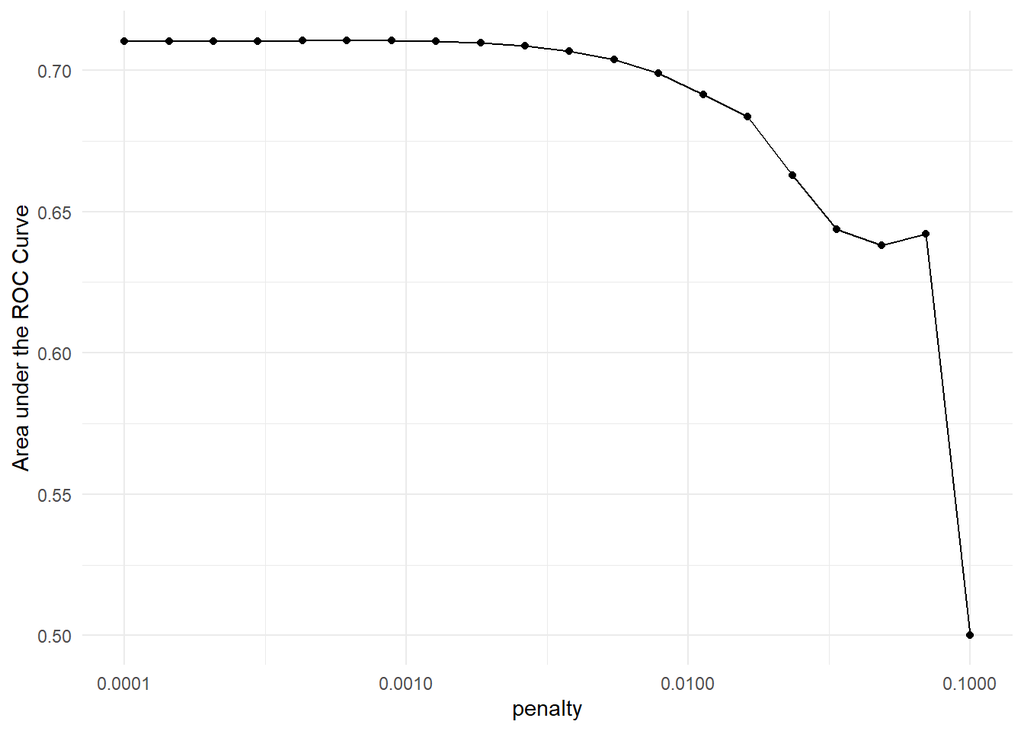

```r
set.seed(3303)
# library(glmnet)
# install.packages("glmnet")

lr_res <- lr_workflow %>%
  tune_grid(resamples = cv_folds,
            grid = lr_reg_grid,
            control = control_grid(save_pred = TRUE),
            metrics = metric_set(roc_auc))

lr_plot <-
  lr_res %>%
  collect_metrics() %>%
  ggplot(aes(x = penalty, y = mean)) +
  geom_point() +
  geom_line() +
  ylab("Area under the ROC Curve") +
  scale_x_log10(labels = scales::label_number())

lr_plot
```

### M1.7 Select best model

Lets try to find the best model…

```r
lr_res %>%
  collect_metrics() %>%
  arrange(penalty) %>%
  rowid_to_column()
```

```
# A tibble: 20 × 8
   rowid  penalty .metric .estimator  mean     n std_err .config
   <int>    <dbl> <chr>   <chr>      <dbl> <int>   <dbl> <chr>
 1     1 0.0001   roc_auc binary     0.710     5 0.00278 Preprocessor1_Model01
 2     2 0.000144 roc_auc binary     0.710     5 0.00279 Preprocessor1_Model02
 3     3 0.000207 roc_auc binary     0.710     5 0.00281 Preprocessor1_Model03
 4     4 0.000298 roc_auc binary     0.710     5 0.00282 Preprocessor1_Model04
 5     5 0.000428 roc_auc binary     0.710     5 0.00285 Preprocessor1_Model05
 6     6 0.000616 roc_auc binary     0.710     5 0.00287 Preprocessor1_Model06
 7     7 0.000886 roc_auc binary     0.710     5 0.00290 Preprocessor1_Model07
 8     8 0.00127  roc_auc binary     0.710     5 0.00300 Preprocessor1_Model08
 9     9 0.00183  roc_auc binary     0.710     5 0.00316 Preprocessor1_Model09
10    10 0.00264  roc_auc binary     0.709     5 0.00333 Preprocessor1_Model10
11    11 0.00379  roc_auc binary     0.707     5 0.00352 Preprocessor1_Model11
12    12 0.00546  roc_auc binary     0.704     5 0.00388 Preprocessor1_Model12
13    13 0.00785  roc_auc binary     0.699     5 0.00397 Preprocessor1_Model13
14    14 0.0113   roc_auc binary     0.691     5 0.00377 Preprocessor1_Model14
15    15 0.0162   roc_auc binary     0.684     5 0.00344 Preprocessor1_Model15
16    16 0.0234   roc_auc binary     0.663     5 0.00424 Preprocessor1_Model16
17    17 0.0336   roc_auc binary     0.644     5 0.00264 Preprocessor1_Model17
18    18 0.0483   roc_auc binary     0.638     5 0.00260 Preprocessor1_Model18
19    19 0.0695   roc_auc binary     0.642     5 0.00253 Preprocessor1_Model19
20    20 0.1      roc_auc binary     0.5       5 0       Preprocessor1_Model20
```

```r
# select optimal penalty
lr_best<-  lr_res %>%
  select_best(metric="roc_auc")
  # collect_metrics() %>%
  # arrange(penalty) %>%
  # slice(12)
#
# lr_res %>%
#   collect_metrics()
```

### M1.8 ROC curve for best fit

OK, now lets see how this ROC curve looks for the best fit log model….

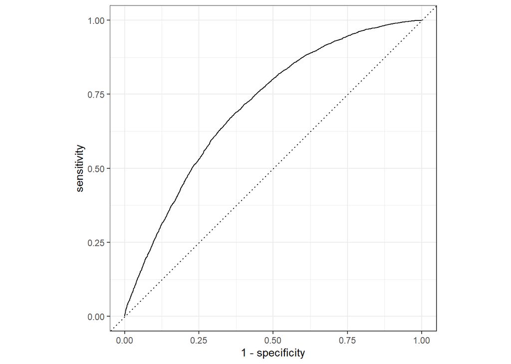

```r
lr_preds1 <- lr_res %>%
  collect_predictions(parameters = lr_best) %>%
  mutate(model_name="Model 1: First Visit Return Failure")

lr_auc<- lr_preds1 %>%
  roc_curve(patient_dropout, .pred_1, event_level = "second") %>%
  mutate(model = "Logistic Regression")

autoplot(lr_auc)
```

```r
# Extract the glmnet model from the workflow and training data
# final_fit <- fit(lr_workflow, data = appts_other)
#
# final_coefficients <- tidy(final_fit, penalty = lr_best$penalty[1], mixture=1)
```

its… ok!

But we can see how it would fit onto the test data now.

### Model 1: Final Fit

```r
last_log_mod <-  logistic_reg(penalty = lr_best$penalty[1], mixture=1) %>%
  set_engine("glmnet", importance="BIC")

# the last workflow
last_log_workflow <- lr_workflow %>%
                    update_model(last_log_mod)

# last fit
last_lr_fit<- last_log_workflow %>%
              fit(training_data)

# show metrics
lr_last_preds_m1 <- predict(last_lr_fit, new_data = testing_data, type="prob") %>%
                bind_cols(testing_data) %>%
                mutate(patient_dropout=as.factor(patient_dropout)) %>%
                mutate(predicted_class_60 = as.factor(if_else(.pred_1 > 0.6, "1", "0"))) %>%
                mutate(predicted_class_50 = as.factor(if_else(.pred_1 > 0.5, "1", "0"))) %>%
                mutate(predicted_class_38 = as.factor(if_else(.pred_1 > 0.38, "1", "0"))) %>%
                mutate(predicted_class_20 = as.factor(if_else(.pred_1 > 0.2, "1", "0"))) %>%
                mutate(predicted_prob_yes = .pred_1, predicted_prob_no = .pred_0) %>%
                mutate("model"="Model 1: Return Failure At Baseline")
```

### M1 Top features

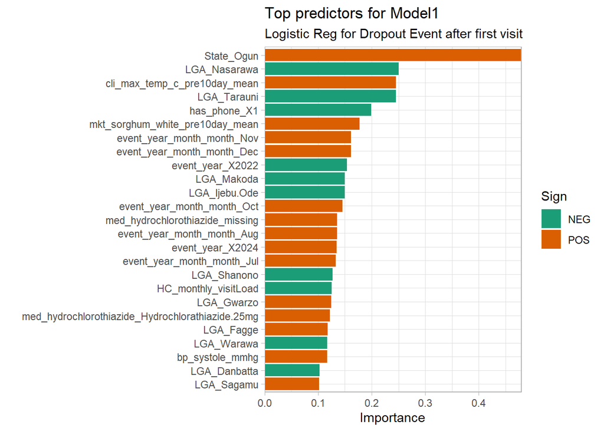

```r
vi_fit<- last_lr_fit %>%
  extract_fit_parsnip()

# vi_test<-vi_fit %>% pluck("fit")
# class(vi_test)

vi_fit %>%
  vip(num_features = 25, mapping=aes(fill=Sign)) +
  scale_y_continuous(expand = c(0,0)) +
  theme_light() +
  labs(title="Top predictors for Model1",
  subtitle="Logistic Reg for Dropout Event after first visit")
```

```r
# pal <- palette.colors(2, palette = "Okabe-Ito")  # colorblind friendly palette
# vip(vi_fit, num_features = 20,  # Figure 3
#     geom = "point", horizontal = FALSE, mapping = aes(color = Sign)) +
#   scale_color_manual(values = unname(pal)) +
#   theme_light() +
#   theme(axis.text.x = element_text(angle = 45, hjust = 1)) +
#   labs(title="Variable Importance in Logistic Regression Model")
```

LGAs seem to have most impact.

Get the coefficients from this final fit [as per docs](https://www.tidymodels.org/learn/models/coefficients/#more-complex-a-glmnet-model)

```r
vi_fit %>% tidy() %>% DT::datatable()
```

|  | term | estimate | penalty |
| --- | --- | --- | --- |
| 1 | (Intercept) | -1.255246441702572 | 0.0008858667904100823 |
| 2 | days_of_medication | 0.002687920937205134 | 0.0008858667904100823 |
| 3 | bp_diastole_mmhg | 0.01339541117828271 | 0.0008858667904100823 |
| 4 | bp_systole_mmhg | 0.1051802866833976 | 0.0008858667904100823 |
| 5 | sbp_baseline | 1.094506240058804e-15 | 0.0008858667904100823 |
| 6 | dbp_baseline | 0.0007774712229359235 | 0.0008858667904100823 |
| 7 | HC_monthly_visitLoad | -0.1032111925243107 | 0.0008858667904100823 |
| 8 | cli_max_temp_c_pre10day_mean | 0.114254511462824 | 0.0008858667904100823 |
| 9 | cli_rain_hours_pre10day_mean | 0.00221417151586073 | 0.0008858667904100823 |
| 10 | cli_rain_mm_pre10day_mean | 0.08607648872017933 | 0.0008858667904100823 |

[output cut: 99 more lines]

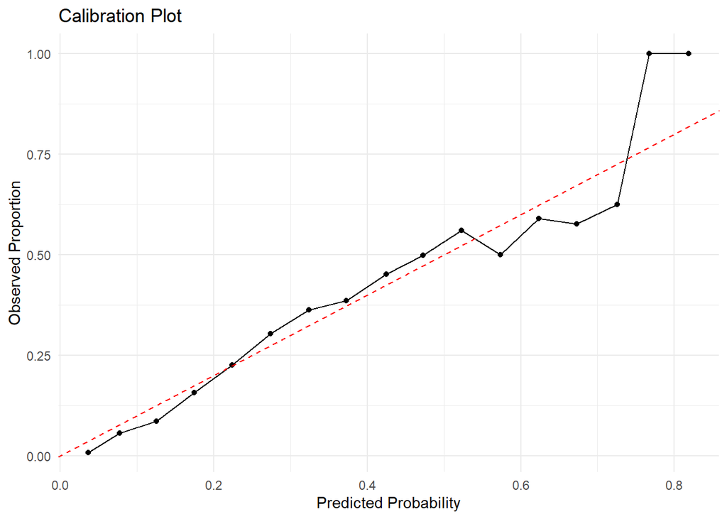

```r
calibration_data <- lr_last_preds_m1 %>%
  mutate(bin = cut(.pred_1, breaks = seq(0, 1, by = 0.05),
                   include.lowest = TRUE)) %>%
  group_by(bin) %>%
  summarize(
    mean_pred = mean(.pred_1),
    observed = mean(as.numeric(patient_dropout) - 1)  # Convert factor to 0/1
  )

ggplot(calibration_data, aes(x = mean_pred, y = observed)) +
  geom_point() +
  geom_line() +
  geom_abline(slope = 1, intercept = 0, linetype = "dashed", color = "red") +
  labs(
    x = "Predicted Probability",
    y = "Observed Proportion",
    title = "Calibration Plot"
  ) +
  theme_minimal()
```

## Model 2: Dropouts Per Opportunity, Full Specs

First prepare the dataset.

```r
dta_model2 <- dta_prep_all_models %>%
  select(reg_id, appt_tally, nextdate_90_kept,
         sex, age, event_year_month, starts_with("days_since"),
         #KEEP FROM HERE
         contains("med"), contains("bp_"), ends_with("baseline"),
         contains("p_step"), relationship_to_patient,
         has_phone, does_patient_have_diabetes,
         "htn_past"=hypertension_treated_in_the_past,
         LGA,
         State, age_group,
         HC_monthly_visitLoad,
         consent_to_send_sms_reminders,
         any_of(pop_params_top) # weather and market params
         ) %>%
  # define the target population (full)
  # filter(appt_tally==1) %>%
  # define the outcome
  mutate(patient_dropout=as.factor(if_else(nextdate_90_kept==1,
                                          0, 1))) %>%
  group_by(reg_id) %>%
  mutate(patient_dropout_ever=if_else(sum(as.numeric(patient_dropout))>0,
                                          1, 0)) %>%
  ungroup() %>%
  select(!any_of(c("visits_since_dropout","nextdate_90_kept",
              "total_patient_visits","registration_date")))
```

### M2.1. Split into training and validation and test sets

```r
library(tidymodels)
set.seed(124)

# Extract unique groups
unique_groups <- unique(dta_model2$reg_id)

# Shuffle groups to ensure random distribution
shuffled_groups <- sample(unique_groups)

# Define the split ratio
split_ratio <- 0.8

# Determine split point
split_point <- floor(length(shuffled_groups) * split_ratio)

# Assign groups to training and validation sets
train_groups <- shuffled_groups[1:split_point]
test_groups <- shuffled_groups[(split_point + 1):length(shuffled_groups)]

# Create training and validation datasets based on group membership
training_data <- dta_model2 %>% filter(reg_id %in% train_groups)
testing_data <- dta_model2 %>% filter(reg_id %in% test_groups)




# Set up 5-fold cross-validation, grouped by the patient ID variable
cv_folds <- group_vfold_cv(training_data, v = 5,
                           group=reg_id, #all visits for one patient go into same fold once the visit is sampled
                           strata=patient_dropout_ever) #same number of patients who eventually dropout go into each fold
```

### M2.2. Build the model

```r
# with lasso regularization

lr_mod <- logistic_reg(penalty = tune(), mixture=1) %>%
  set_engine("glmnet")
```

### M2.3. Build the “recipe” to preprocess the data

```r
lr_recipe <- recipe(patient_dropout ~ ., data = training_data) %>%
  update_role(reg_id, new_role = "ID") %>%
  # step_date(event_date, features = c("dow", "month")) %>%
  step_date(event_year_month, features = c("month")) %>%
  # step_date(exp_year_month, features = c("year", "month")) %>%
  # step_rm(event_date) %>%
  step_rm(patient_dropout_ever) %>%
  step_rm(event_year_month) %>%
  step_log(appt_tally) %>%
  step_log(HC_monthly_visitLoad) %>%
  # step_rm(exp_year_month) %>%
  # Step to impute missing values in factor_var (if NA is not a valid level)
  step_novel(all_factor_predictors(), new_level = "new") %>%
  step_unknown(all_factor_predictors(), new_level = "missing") %>%
  # Step to impute missing values in numeric variable x with mean
  step_impute_median(all_numeric_predictors()) %>%
  # step_rose(patient_dropout) %>% # this didnt help...
  # step_corr(all_numeric_predictors(), threshold = .5) %>%
  step_dummy(all_nominal_predictors()) %>%
  step_ns(age) %>% #
  # step_ns(sbp_change_from_baseline) %>%
  step_zv(all_predictors()) %>%
  step_normalize(all_predictors())
```

### M2.4 Combining the model and recipe into workflow

```r
lr_workflow<-workflow() %>%
  add_model(lr_mod) %>%
  add_recipe(lr_recipe)
```

### M2.5. Penalty values for tuning

```r
lr_reg_grid <- tibble(penalty = 10^seq(-4, -1, length.out = 20))
```

### M2.6. Apply penalty values to the workflow

[figure not shown]

```r
set.seed(3303)
# library(glmnet)
# install.packages("glmnet")

lr_res <- lr_workflow %>%
  tune_grid(resamples = cv_folds,
            grid = lr_reg_grid,
            control = control_grid(save_pred = TRUE),
            metrics = metric_set(roc_auc))

lr_plot <-
  lr_res %>%
  collect_metrics() %>%
  ggplot(aes(x = penalty, y = mean)) +
  geom_point() +
  geom_line() +
  ylab("Area under the ROC Curve") +
  scale_x_log10(labels = scales::label_number()) +
  geom_vline(xintercept=lr_best$penalty,
             linetype="dashed", color="blue") +
  annotate(geom="text",
           x=lr_best$penalty+0.0008, y=0.721, color="blue", size=4,
           label=paste0("Optimum = ",round(lr_best$penalty, 6))) +
  labs(title="Tune grid of penalty values")

lr_plot
```

### M2.7. Select best model

```r
lr_res %>%
  collect_metrics() %>%
  arrange(penalty) %>%
  rowid_to_column()
```

```
# A tibble: 20 × 8
   rowid  penalty .metric .estimator  mean     n std_err .config
   <int>    <dbl> <chr>   <chr>      <dbl> <int>   <dbl> <chr>
 1     1 0.0001   roc_auc binary     0.736     5 0.00167 Preprocessor1_Model01
 2     2 0.000144 roc_auc binary     0.736     5 0.00167 Preprocessor1_Model02
 3     3 0.000207 roc_auc binary     0.736     5 0.00165 Preprocessor1_Model03
 4     4 0.000298 roc_auc binary     0.736     5 0.00164 Preprocessor1_Model04
 5     5 0.000428 roc_auc binary     0.736     5 0.00162 Preprocessor1_Model05
 6     6 0.000616 roc_auc binary     0.736     5 0.00161 Preprocessor1_Model06
 7     7 0.000886 roc_auc binary     0.735     5 0.00159 Preprocessor1_Model07
 8     8 0.00127  roc_auc binary     0.735     5 0.00157 Preprocessor1_Model08
 9     9 0.00183  roc_auc binary     0.734     5 0.00155 Preprocessor1_Model09
10    10 0.00264  roc_auc binary     0.733     5 0.00154 Preprocessor1_Model10
11    11 0.00379  roc_auc binary     0.731     5 0.00147 Preprocessor1_Model11
12    12 0.00546  roc_auc binary     0.729     5 0.00136 Preprocessor1_Model12
13    13 0.00785  roc_auc binary     0.726     5 0.00131 Preprocessor1_Model13
14    14 0.0113   roc_auc binary     0.721     5 0.00131 Preprocessor1_Model14
15    15 0.0162   roc_auc binary     0.715     5 0.00142 Preprocessor1_Model15
16    16 0.0234   roc_auc binary     0.710     5 0.00134 Preprocessor1_Model16
17    17 0.0336   roc_auc binary     0.702     5 0.00185 Preprocessor1_Model17
18    18 0.0483   roc_auc binary     0.695     5 0.00177 Preprocessor1_Model18
19    19 0.0695   roc_auc binary     0.682     5 0.00194 Preprocessor1_Model19
20    20 0.1      roc_auc binary     0.682     5 0.00194 Preprocessor1_Model20
```

```r
# select optimal penalty
lr_best<-  lr_res %>%
  select_best(metric="roc_auc")
  # collect_metrics() %>%
  # arrange(penalty) %>%
  # slice(12)

lr_best
```

```
# A tibble: 1 × 2
   penalty .config
     <dbl> <chr>
1 0.000428 Preprocessor1_Model05
```

### M2.8. ROC curve for best fit

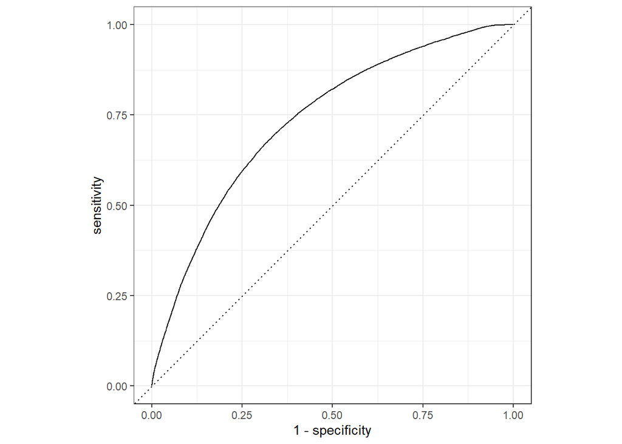

```r
lr_preds2 <- lr_res %>%
  collect_predictions(parameters = lr_best) %>%
  mutate(model_name="Model 2: Dropout Per Opp (Full Spec)")


lr_auc<- lr_preds2 %>%
  roc_curve(patient_dropout, .pred_1, event_level = "second") %>%
  mutate(model = "Logistic Regression")

roc_plot<-lr_auc

autoplot(lr_auc)
```

[figure not shown]

```r
library(patchwork)
roc_plot<-autoplot(lr_auc) +
  labs(title="ROC Curve")

lr_plot +
  roc_plot +
   plot_annotation(tag_levels = 'A') +
   theme_minimal()
```

```r
my_ggsave("fig6_roc_penalty", 14)
```

its… ok!

But we can see how it would fit onto the test data now.

### Model 2: Final Fit

```r
last_log_mod <-  logistic_reg(penalty = lr_best$penalty[1], mixture=1) %>%
  set_engine("glmnet", importance="BIC")

# the last workflow
last_log_workflow <- lr_workflow %>%
                    update_model(last_log_mod)


# last fit
last_lr_fit<- last_log_workflow %>%
              fit(training_data)

lr_last_preds_m2 <- predict(last_lr_fit, new_data = testing_data, type="prob") %>%
                bind_cols(testing_data) %>%
                mutate(patient_dropout=as.factor(patient_dropout)) %>%
                  mutate(predicted_class_60 = as.factor(if_else(.pred_1 > 0.6, "1", "0"))) %>%
                mutate(predicted_class_50 = as.factor(if_else(.pred_1 > 0.5, "1", "0"))) %>%
                mutate(predicted_class_38 = as.factor(if_else(.pred_1 > 0.38, "1", "0"))) %>%
                mutate(predicted_class_20 = as.factor(if_else(.pred_1 > 0.2, "1", "0"))) %>%
                mutate(predicted_prob_yes = .pred_1, predicted_prob_no = .pred_0) %>%
                mutate("model"="Model 2: Full Spec")
```

### Model 2: Performance Metrics

```r
# Define classification metrics
classification_metrics <- metric_set(accuracy, precision, recall,
                                     f_meas, roc_auc, j_index)


# Calculate performance metrics
performance_50 <- classification_metrics(lr_last_preds_m2, truth = patient_dropout,
                                      predicted_prob_yes,
                                      estimate=predicted_class_50,
                                      event_level="second") %>% mutate(cutoff=0.5)


# Calculate performance metrics
performance_38 <- classification_metrics(lr_last_preds_m2, truth = patient_dropout,
                                      predicted_prob_yes,
                                      estimate=predicted_class_38,
                                      event_level="second") %>% mutate(cutoff=0.38)


performance<-bind_rows(performance_38, performance_50) %>%
             pivot_wider(id_cols = cutoff,
                        names_from=.metric, values_from=.estimate) %>%
             rename("sensitivity"=recall) %>%
             mutate(across(everything()), round(.,3))


performance
```

```
# A tibble: 2 × 7
  cutoff accuracy precision sensitivity f_meas j_index roc_auc
   <dbl>    <dbl>     <dbl>       <dbl>  <dbl>   <dbl>   <dbl>
1   0.38    0.741     0.504       0.477  0.491   0.311   0.742
2   0.5     0.751     0.564       0.204  0.3     0.148   0.742
```

```r
write_csv(performance, here::here("data","model_performance_latest.csv"))
```

### M2 Subgroup analysis

```r
# Calculate performance metrics, by subgroups
metrics_by_subgroup <- function(data, sex_c, state_c,pred_class){

  data %>%
    filter(
      case_when(
        sex_c=="Male" ~ sex==sex_c,
        sex_c=="Female" ~ sex==sex_c,
        TRUE ~ TRUE)) %>%
      filter(
        case_when(
          state_c=="Kano" ~ State==state_c,
          state_c=="Ogun" ~ State==state_c,
          TRUE ~ TRUE)) %>%
   classification_metrics(., truth = patient_dropout,
                                      predicted_prob_yes,
                                      estimate=pred_class,
                                      event_level="second") %>%
                                      mutate(cutoff=pred_class,
                                             sex=sex_c,
                                             state=state_c) %>%
    mutate(sex=if_else(sex=="Male"|sex=="Female",sex,"both")) %>%
    mutate(state=if_else(state_c=="Kano"|state_c=="Ogun",state_c,"both"))
  }

# metrics_by_subgroup(lr_last_preds_m2,"Male","Kano","predicted_class_50")
# metrics_by_subgroup(lr_last_preds_m2,statgrid[1,])
# metrics_by_subgroup(lr_last_preds_m2, "predicted_class_50","Male","Kano")

statgrid<-tidyr::expand_grid(sex=c("Male","Female","both"),
                   state=c("Kano","Ogun","both"),
                   pred=c("predicted_class_50","predicted_class_38"))



stats_all_groups<-map(1:nrow(statgrid), function(x)
                    metrics_by_subgroup(lr_last_preds_m2,
                        statgrid$sex[x],statgrid$state[x],statgrid$pred[x])) %>%
                        bind_rows()  %>%
                    select(!.estimator) %>%
                    mutate(.metric=if_else(.metric=="recall","sensitivity",.metric)) %>%
                    mutate(across(is.numeric, ~round(.,3))) %>%
                    mutate(threshold=str_replace_all(cutoff,"predicted_class_","0."))



stats_all_groups_wide <-stats_all_groups %>%
              pivot_wider(names_from=.metric, values_from=.estimate) %>%
              select(state,sex,threshold,everything()) %>%
              arrange(state,sex,threshold)

write_csv(stats_all_groups_wide,
          here::here("data","model_subgroupstats_latest.csv"))

stats_all_groups_wide %>%
  DT::datatable()
```

|  | state | sex | threshold | cutoff | accuracy | precision | sensitivity | f_meas | j_index | roc_auc |
| --- | --- | --- | --- | --- | --- | --- | --- | --- | --- | --- |
| 1 | Kano | Female | 0.38 | predicted_class_38 | 0.766 | 0.477 | 0.386 | 0.426 | 0.262 | 0.739 |
| 2 | Kano | Female | 0.50 | predicted_class_50 | 0.78 | 0.54 | 0.18 | 0.27 | 0.135 | 0.739 |
| 3 | Kano | Male | 0.38 | predicted_class_38 | 0.749 | 0.481 | 0.419 | 0.448 | 0.274 | 0.74 |
| 4 | Kano | Male | 0.50 | predicted_class_50 | 0.775 | 0.593 | 0.245 | 0.347 | 0.191 | 0.74 |
| 5 | Kano | both | 0.38 | predicted_class_38 | 0.762 | 0.478 | 0.393 | 0.431 | 0.265 | 0.739 |
| 6 | Kano | both | 0.50 | predicted_class_50 | 0.779 | 0.553 | 0.194 | 0.287 | 0.147 | 0.739 |
| 7 | Ogun | Female | 0.38 | predicted_class_38 | 0.703 | 0.52 | 0.57 | 0.544 | 0.333 | 0.724 |
| 8 | Ogun | Female | 0.50 | predicted_class_50 | 0.703 | 0.562 | 0.201 | 0.296 | 0.13 | 0.724 |
| 9 | Ogun | Male | 0.38 | predicted_class_38 | 0.7 | 0.551 | 0.63 | 0.588 | 0.366 | 0.743 |
| 10 | Ogun | Male | 0.50 | predicted_class_50 | 0.69 | 0.605 | 0.252 | 0.356 | 0.168 | 0.743 |

[output cut: 8 more lines]

Subgroup analysis plot

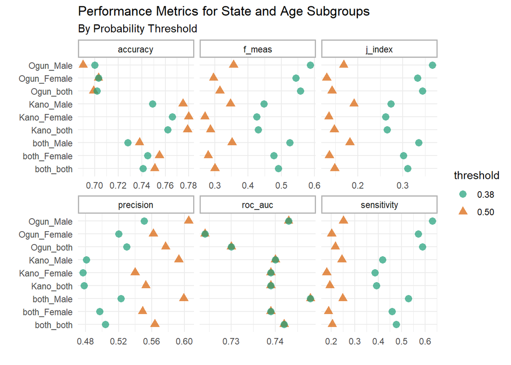

```r
# stats_all_groups %>%
#         select(state,sex,cutoff,everything()) %>%
#         # filter(cutoff=="0.38") %>%
#         unite(col="group",1:2,sep="_",remove=F) %>%
#         pivot_wider(names_from=cutoff, values_from=.estimate, names_prefix = "cutoff_") %>%
#         ggplot(aes(x=group)) +
#         geom_point(aes(y=cutoff_0.50, fill="0.50"), alpha=0.5, size=2) +
#         geom_point(aes(y=cutoff_0.38, fill="0.38"), alpha=0.5, size=2) +
#         scale_fill_manual(values = c("red", "green"), name = "Cutoff",
#                   guide = guide_legend(reverse = TRUE)) +
#         geom_segment(aes(x=group, xend=group,
#                          y=cutoff_0.38,
#                          yend=cutoff_0.50), alpha=0.5) +
#         coord_flip() +
#         facet_wrap(~.metric,scales = "free_x",nrow=2) +
#         labs(title="Performance Metrics by State and Age Subgroups",
#              subtitle="By Cutoff Point", x="", y="")



stats_all_groups %>%
        select(state,sex,threshold,everything()) %>%
        # filter(cutoff=="0.38") %>%
        unite(col="group",1:2,sep="_",remove=F) %>%
        ggplot(aes(x=group,y=.estimate)) +
        geom_point(aes(shape=threshold, color=threshold), alpha=0.7, size=3) +
        coord_flip() +
        facet_wrap(~.metric,scales = "free_x",nrow=2) +
        labs(title="Performance Metrics for State and Age Subgroups",
             subtitle="By Probability Threshold", x="", y="")
```

```r
my_ggsave("fig7_subgroup_analyses",10)
```

```r
# # Extract the number of observations in each fold
# fold_sizes <- cv_folds %>%
#   mutate(
#     training_size = map_int(splits, ~ nrow(analysis(.))),
#     validation_size = map_int(splits, ~ nrow(assessment(.)))
#   )
#
# # Print the results
# fold_sizes %>%
#   select(id, training_size, validation_size) %>%
#   mutate(sum=training_size+validation_size)

# dta_model2 %>%
#   janitor::tabyl(patient_dropout)
```

### M2 Net Benefit Analysis

```r
lr_last_preds_m2 %>%
      reframe(tp=if_else(predicted_class_50==1 & patient_dropout==1, 1, 0),
         fp=if_else(predicted_class_50==1 & patient_dropout==0, 1, 0)) %>%
      summarise(tp=sum(tp),
                fp=sum(fp),
                n=nrow(.)) %>% t()
```

```
    [,1]
tp  1063
fp   822
n  19948
```

```r
# (4195/19948)-(6896/19948) * (0.2/(1-0.2))
#
# (2489/19948)-(2446/19948) * (0.38/(1-0.38))

(1063/19948)-(822/19948) * (0.5/(1-0.5))
```

```
[1] 0.01208141
```

About same ROC as with validation set…

### M2 Top features

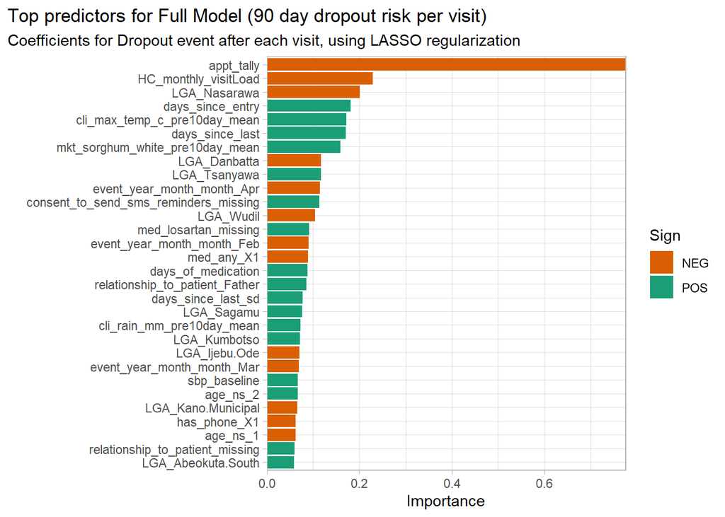

```r
vi_fit<- last_lr_fit

vi_fit %>%
  vip(num_features = 30, mapping=aes(fill=Sign)) +
  scale_y_continuous(expand = c(0,0)) +
  theme_light() +
  labs(title="Top predictors for Full Model (90 day dropout risk per visit)",
  subtitle="Coefficients for Dropout event after each visit, using LASSO regularization") +
  theme(plot.title.position = "plot") +
  scale_fill_manual(values = c(palette[2],palette[1]))
```

```r
my_ggsave("fig5_top_predictors_latest", 10)
```

Get the coefficients from this final fit [as per docs](https://www.tidymodels.org/learn/models/coefficients/#more-complex-a-glmnet-model)

```r
last_lr_fit %>% broom::tidy() %>%
 DT::datatable()
```

[output not shown]

[output cut: 106 more lines]

### M2 Calibration plot

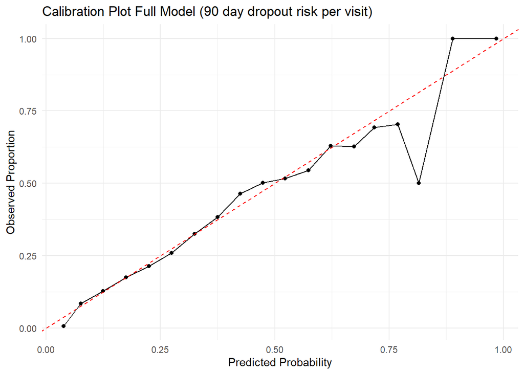

```r
lr_last_preds_m2 %>%
  mutate(bin = cut(predicted_prob_yes, breaks = seq(0, 1, by = 0.05),
                   include.lowest = TRUE)) %>%
  group_by(bin) %>%
  reframe(model=model,
    mean_pred = mean(predicted_prob_yes),
    observed = mean(as.numeric(patient_dropout) - 1)  # Convert factor to 0/1
  ) %>%
ggplot(aes(x = mean_pred, y = observed)) +
  geom_point() +
  geom_line() +
  geom_abline(slope = 1, intercept = 0, linetype = "dashed", color = "red") +
  labs(
    x = "Predicted Probability",
    y = "Observed Proportion",
    title = paste0("Calibration Plot Full Model (90 day dropout risk per visit)"))
```

```r
my_ggsave("fig4_model_calplot_latest",10)
```

Whats the distribution of estimated probabilities?

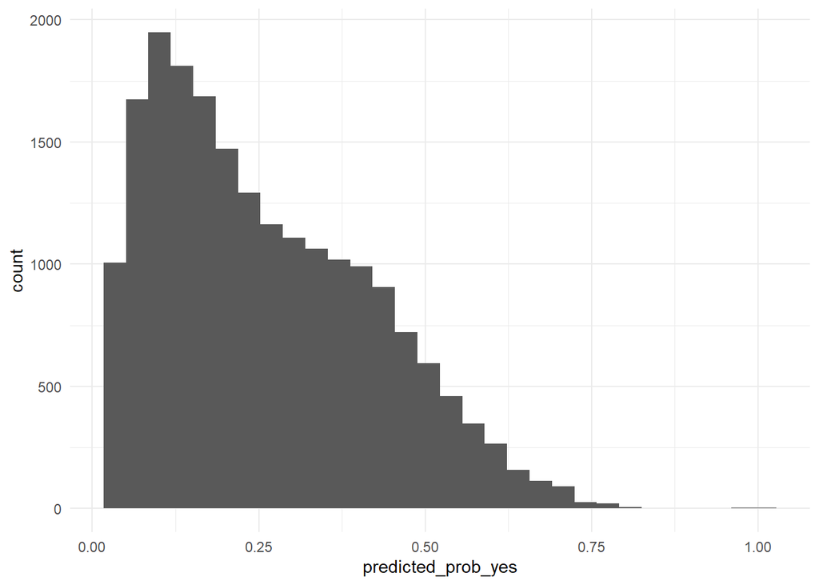

```r
lr_last_preds_m2 %>%
  ggplot() +
  geom_histogram(aes(x=predicted_prob_yes))
```

Only 9% are greated than 50% likelihood. But we know theres an attrition rate twice as high.

```r
lr_last_preds_m2 %>%
  janitor::tabyl(predicted_class_50)
```

```
 predicted_class_50     n    percent
                  0 18063 0.90550431
                  1  1885 0.09449569
```

```r
lr_last_preds_m2 %>%
  mutate(over70=if_else(predicted_prob_yes>=0.7, 1, 0)) %>%
    janitor::tabyl(over70)
```

```
 over70     n     percent
      0 19833 0.994235011
      1   115 0.005764989
```

## Model 3: Dropouts Per Opportunity, Parsimonious

First prepare the dataset.

```r
dta_model3 <- dta_prep_all_models %>%
  select(reg_id, appt_tally, nextdate_90_kept, event_date,
         event_year_month, days_since_entry,
         sex, age, event_year, days_since_last,
         #KEEP FROM HERE
         contains("med"), contains("bp_"), ends_with("baseline"),
         contains("p_step"), relationship_to_patient,
         has_phone, does_patient_have_diabetes,
         State,age_group,
         HC_monthly_visitLoad,
         consent_to_send_sms_reminders,
         any_of(pop_params_top) # weather and market params
         ) %>%
  # define the target population (baseline)
  # filter(appt_tally==1) %>%
  # define the outcome
  mutate(patient_dropout=if_else(nextdate_90_kept==1,
                                          0, 1)) %>%
  group_by(reg_id) %>%
  mutate(patient_dropout_ever=if_else(sum(patient_dropout)>0,
                                          1, 0)) %>%
  ungroup() %>%
  mutate(patient_dropout=as.factor(patient_dropout)) %>%
# PARSIMONIOUS VARIABLE SET
  select(reg_id, patient_dropout, patient_dropout_ever,
          starts_with("days_since"),
          appt_tally,event_year_month)
```

### M3.1. Split into training and validation and test sets

```r
library(tidymodels)
set.seed(124)

# Extract unique groups
unique_groups <- unique(dta_model3$reg_id)

# Shuffle groups to ensure random distribution
shuffled_groups <- sample(unique_groups)

# Define the split ratio
split_ratio <- 0.8

# Determine split point
split_point <- floor(length(shuffled_groups) * split_ratio)

# Assign groups to training and validation sets
train_groups <- shuffled_groups[1:split_point]
test_groups <- shuffled_groups[(split_point + 1):length(shuffled_groups)]

# Create training and validation datasets based on group membership
training_data <- dta_model3 %>% filter(reg_id %in% train_groups)
testing_data <- dta_model3 %>% filter(reg_id %in% test_groups)




# Set up 5-fold cross-validation, grouped by the patient ID variable
cv_folds <- group_vfold_cv(training_data, v = 5,
                           group=reg_id, #all visits for one patient go into same fold once the visit is sampled
                           strata=patient_dropout_ever) #same number of patients who eventually dropout go into each fold
```

### M3.2. Build the model

```r
# with lasso regularization

lr_mod <- logistic_reg(penalty = tune(), mixture=1) %>%
  set_engine("glmnet")
```

### M3.3. Build the “recipe” to preprocess the data

```r
lr_recipe <- recipe(patient_dropout ~ ., data = dta_model3) %>%
  update_role(reg_id, new_role = "ID") %>%
  # step_date(event_date, features = c("dow", "month")) %>%
  step_date(event_year_month, features = c("month")) %>%
  step_rm(patient_dropout_ever) %>%
  step_rm(event_year_month) %>%
# these two have an exponential descent, so log them
  step_log(appt_tally) %>%
  # step_rm(exp_year_month) %>%
  # Step to impute missing values in factor_var (if NA is not a valid level)
  step_novel(all_factor_predictors(), new_level = "new") %>%
  step_unknown(all_factor_predictors(), new_level = "missing") %>%
  # Step to impute missing values in numeric variable x with mean
  step_impute_median(all_numeric_predictors()) %>%
  # step_corr(all_numeric_predictors(), threshold = .5) %>%
  step_dummy(all_nominal_predictors()) %>%
  # step_ns(sbp_change_from_baseline) %>%
  step_zv(all_predictors()) %>%
  step_normalize(all_predictors())
```

### M3.4. Combine model and recipe into a workflow

```r
lr_workflow<-workflow() %>%
  add_model(lr_mod) %>%
  add_recipe(lr_recipe)
```

### M3.5. Create penalty values for tuning

```r
lr_reg_grid <- tibble(penalty = 10^seq(-4, -1, length.out = 20))
```

### M3.6. apply penalty values to the workflow

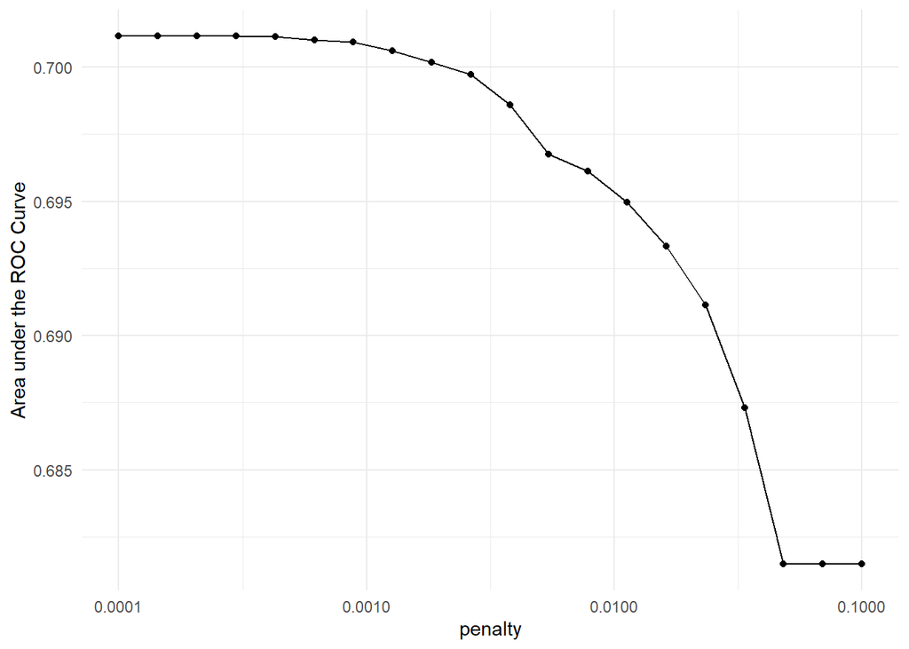

```r
set.seed(3303)
library(glmnet)
# install.packages("glmnet")

lr_res <- lr_workflow %>%
  tune_grid(resamples = cv_folds,
            grid = lr_reg_grid,
            control = control_grid(save_pred = TRUE),
            metrics = metric_set(roc_auc))

lr_plot <-
  lr_res %>%
  collect_metrics() %>%
  ggplot(aes(x = penalty, y = mean)) +
  geom_point() +
  geom_line() +
  ylab("Area under the ROC Curve") +
  scale_x_log10(labels = scales::label_number())

lr_plot
```

### M3.7. Select best model penalty

```r
lr_res %>%
  collect_metrics() %>%
  arrange(penalty) %>%
  rowid_to_column()
```

```
# A tibble: 20 × 8
   rowid  penalty .metric .estimator  mean     n std_err .config
   <int>    <dbl> <chr>   <chr>      <dbl> <int>   <dbl> <chr>
 1     1 0.0001   roc_auc binary     0.701     5 0.00384 Preprocessor1_Model01
 2     2 0.000144 roc_auc binary     0.701     5 0.00384 Preprocessor1_Model02
 3     3 0.000207 roc_auc binary     0.701     5 0.00384 Preprocessor1_Model03
 4     4 0.000298 roc_auc binary     0.701     5 0.00384 Preprocessor1_Model04
 5     5 0.000428 roc_auc binary     0.701     5 0.00384 Preprocessor1_Model05
 6     6 0.000616 roc_auc binary     0.701     5 0.00387 Preprocessor1_Model06
 7     7 0.000886 roc_auc binary     0.701     5 0.00389 Preprocessor1_Model07
 8     8 0.00127  roc_auc binary     0.701     5 0.00394 Preprocessor1_Model08
 9     9 0.00183  roc_auc binary     0.700     5 0.00395 Preprocessor1_Model09
10    10 0.00264  roc_auc binary     0.700     5 0.00408 Preprocessor1_Model10
11    11 0.00379  roc_auc binary     0.699     5 0.00411 Preprocessor1_Model11
12    12 0.00546  roc_auc binary     0.697     5 0.00412 Preprocessor1_Model12
13    13 0.00785  roc_auc binary     0.696     5 0.00405 Preprocessor1_Model13
14    14 0.0113   roc_auc binary     0.695     5 0.00403 Preprocessor1_Model14
15    15 0.0162   roc_auc binary     0.693     5 0.00400 Preprocessor1_Model15
16    16 0.0234   roc_auc binary     0.691     5 0.00408 Preprocessor1_Model16
17    17 0.0336   roc_auc binary     0.687     5 0.00400 Preprocessor1_Model17
18    18 0.0483   roc_auc binary     0.681     5 0.00396 Preprocessor1_Model18
19    19 0.0695   roc_auc binary     0.681     5 0.00396 Preprocessor1_Model19
20    20 0.1      roc_auc binary     0.681     5 0.00396 Preprocessor1_Model20
```

```r
# select optimal penalty
lr_best<-  lr_res %>%
  select_best(metric="roc_auc")
  # collect_metrics() %>%
  # arrange(penalty) %>%
  # slice(12)
```

### M3.8. ROC Curve for best fit

```r
lr_preds3 <- lr_res %>%
  collect_predictions(parameters = lr_best) %>%
  mutate(model_name="Model 3: Dropout Per Opp (Minimal Spec)")

lr_auc<- lr_preds3 %>%
  roc_curve(patient_dropout, .pred_1, event_level = "second") %>%
  mutate(model = "Logistic Regression")
```

its… ok!

### Model 3: Final Fit

```r
last_log_mod <-  logistic_reg(penalty = lr_best$penalty[1], mixture=1) %>%
  set_engine("glmnet", importance="BIC")

# the last workflow
last_log_workflow <- lr_workflow %>%
                    update_model(last_log_mod)


# last fit
last_lr_fit<- last_log_workflow %>%
              fit(training_data)

lr_last_preds_m3 <- predict(last_lr_fit, new_data = testing_data, type="prob") %>%
                bind_cols(testing_data) %>%
                mutate(patient_dropout=as.factor(patient_dropout)) %>%
                 mutate(predicted_class_60 = as.factor(if_else(.pred_1 > 0.6, "1", "0"))) %>%
                mutate(predicted_class_50 = as.factor(if_else(.pred_1 > 0.5, "1", "0"))) %>%
                mutate(predicted_class_38 = as.factor(if_else(.pred_1 > 0.38, "1", "0"))) %>%
                mutate(predicted_class_20 = as.factor(if_else(.pred_1 > 0.2, "1", "0"))) %>%
                mutate(predicted_prob_yes = .pred_1, predicted_prob_no = .pred_0) %>%
                mutate("model"="Model 3: Minimal Spec")
```

About same ROC as with validation set…

### M3 Top features

Fitting the model to the full dataset…

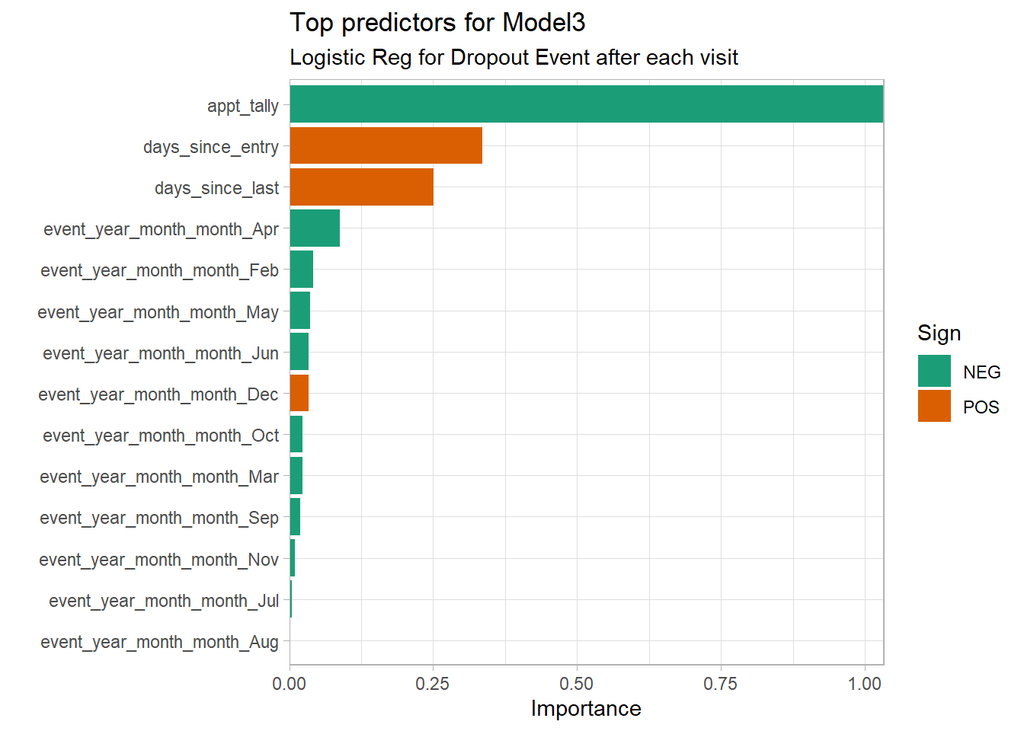

```r
library(vip)
vi_fit<- last_lr_fit


vi_fit %>%
  vip(num_features = 25, mapping=aes(fill=Sign)) +
  scale_y_continuous(expand = c(0,0)) +
  theme_light() +
  labs(title="Top predictors for Model3",
  subtitle="Logistic Reg for Dropout Event after each visit")
```

Appointment Count and Days Since Entry (Registration) seem STILL to have greatest impact.

Get the coefficients from this final fit [as per docs](https://www.tidymodels.org/learn/models/coefficients/#more-complex-a-glmnet-model)

```r
vi_fit %>% tidy() %>% DT::datatable()
```

|  | term | estimate | penalty |
| --- | --- | --- | --- |
| 1 | (Intercept) | -1.17454630540153 | 0.0002976351441631319 |
| 2 | days_since_entry | 0.3357484108045889 | 0.0002976351441631319 |
| 3 | days_since_last | 0.2508567682167784 | 0.0002976351441631319 |
| 4 | appt_tally | -1.032386646810783 | 0.0002976351441631319 |
| 5 | event_year_month_month_Feb | -0.041597757210218 | 0.0002976351441631319 |
| 6 | event_year_month_month_Mar | -0.0232476774270071 | 0.0002976351441631319 |
| 7 | event_year_month_month_Apr | -0.08791995905217795 | 0.0002976351441631319 |
| 8 | event_year_month_month_May | -0.03687279537239253 | 0.0002976351441631319 |
| 9 | event_year_month_month_Jun | -0.03426976493883774 | 0.0002976351441631319 |
| 10 | event_year_month_month_Jul | -0.004766084098808847 | 0.0002976351441631319 |

[output cut: 5 more lines]

# Model Calibration Comparison

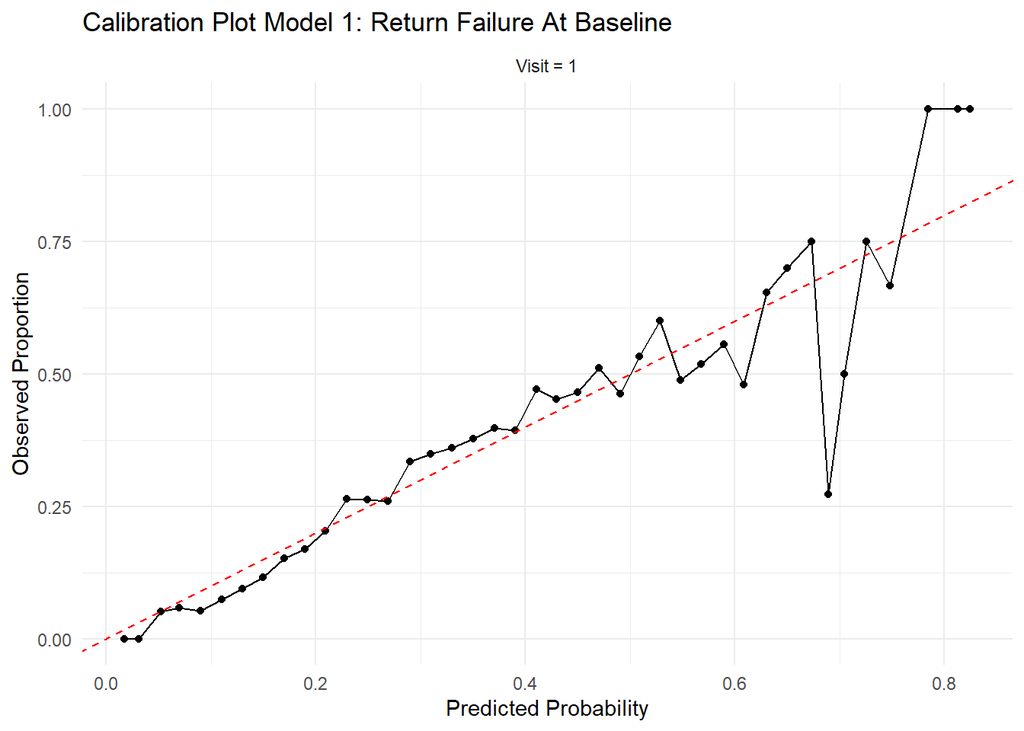

```r
theme_set(theme_minimal())

make_cal_plot <-function(predictions, basedata){

calibration_data <- predictions %>%
    mutate(appt_tally_level =
      case_when(
        appt_tally==1 ~ "Visit = 1",
        appt_tally>1 & appt_tally < 6 ~ "Visit = 2 to 5",
        TRUE ~ "Visit = 6+"
      )
    ) %>%
  mutate(bin = cut(predicted_prob_yes, breaks = seq(0, 1, by = 0.02),
                   include.lowest = TRUE)) %>%
  group_by(appt_tally_level, bin) %>%
  reframe(model=model,
    mean_pred = mean(.pred_1),
    observed = mean(as.numeric(patient_dropout) - 1)  # Convert factor to 0/1
  )
ggplot(calibration_data, aes(x = mean_pred, y = observed)) +
  geom_point() +
  geom_line() +
  geom_abline(slope = 1, intercept = 0, linetype = "dashed", color = "red") +
  labs(
    x = "Predicted Probability",
    y = "Observed Proportion",
    title = paste0("Calibration Plot ", unique(calibration_data$model))) +
  facet_wrap(~appt_tally_level, ncol=1)
}



make_cal_plot(lr_last_preds_m1, dta_model1)
```

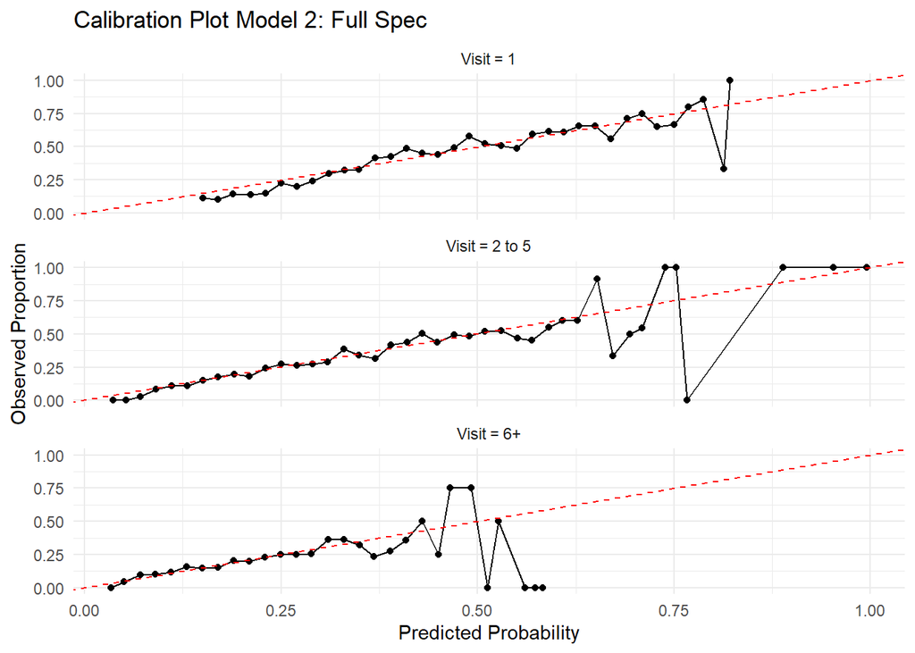

```r
make_cal_plot(lr_last_preds_m2, dta_model2)
```

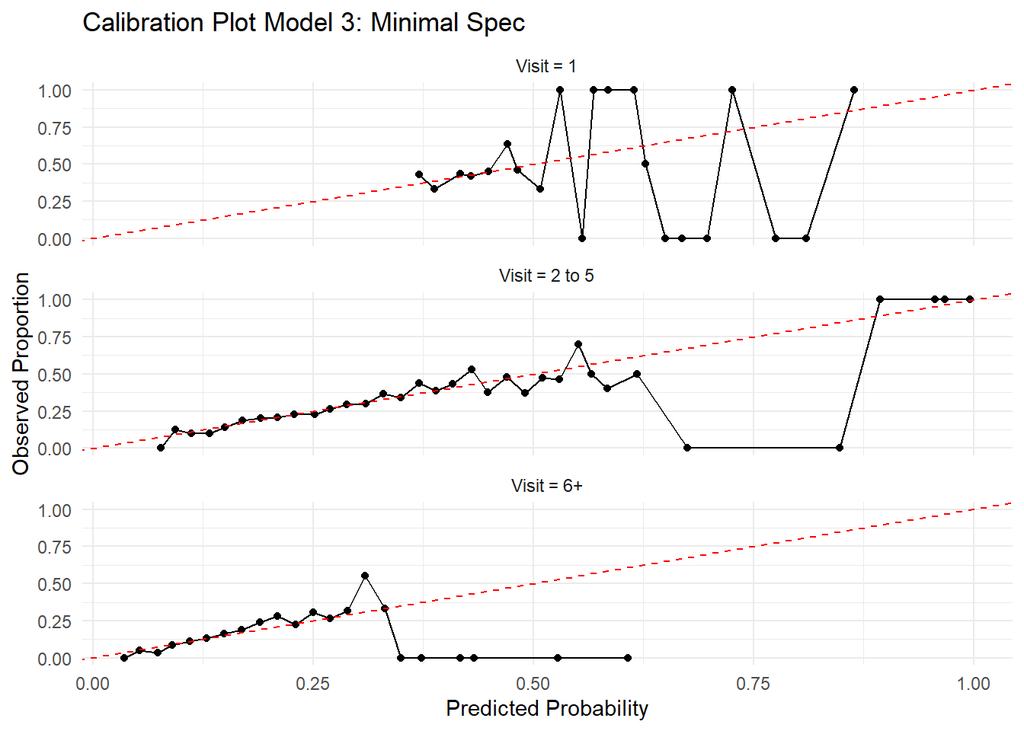

```r
make_cal_plot(lr_last_preds_m3, dta_model3)
```

# Model Performance Comparison

[figure not shown]

```r
bind_rows(
  lr_last_preds_m1,
  lr_last_preds_m2,
  lr_last_preds_m3
    ) %>%
    mutate(model =
      case_when(
        model=="Model 1" ~ str_wrap("Model 1: Return Failure Post Baseline",15),
        model=="Model 2" ~ str_wrap("Model 2: Dropout Per Opp (Full Spec)",15),
        model=="Model 3" ~ str_wrap("Model 3: Dropout Per Opp (Minimal Spec)",15),
      )
    ) %>%
  group_by(model) %>%
  roc_curve(patient_dropout, .pred_1, event_level = "second") %>%
  autoplot() +
  labs(title="ROC Curve: sensitivity comparison of discrimination") +
  theme_set(mytheme) +
  theme(legend.key.size = unit(2, "cm"))
```

```r
my_ggsave("roc_curve_compare",9)
```

Show metrics for last fits

```r
my_metrics <- function(predictions){
# Calculate performance metrics
classification_metrics(predictions, truth = patient_dropout,
                                      predicted_prob_yes,
                                      estimate=predicted_class_38,
                                      event_level="second") %>%
                                      mutate(model=unique(predictions$model))
  }


lr_last_all<-list(lr_last_preds_m1,
                   lr_last_preds_m2,
                   lr_last_preds_m3)


r3<-function(x){round(x,3)}


metrics_comparison<-map(lr_last_all,my_metrics) %>%
                    bind_rows() %>%
                  select(model,.metric, .estimate) %>%
                  pivot_wider(names_from=.metric, values_from=.estimate) %>%
                  rename("sensitivity"=recall) %>%
                  mutate(across(where(is.double), r3))

write_csv(metrics_comparison,
          here::here("data","model_comparison_latest.csv"))

metrics_comparison %>%
  kable()
```

| model | accuracy | precision | sensitivity | f_meas | j_index | roc_auc |
| --- | --- | --- | --- | --- | --- | --- |
| Model 1: Return Failure At Baseline | 0.756 | 0.494 | 0.313 | 0.383 | 0.211 | 0.735 |
| Model 2: Full Spec | 0.741 | 0.504 | 0.477 | 0.491 | 0.311 | 0.742 |
| Model 3: Minimal Spec | 0.703 | 0.438 | 0.487 | 0.461 | 0.266 | 0.704 |